UFSM: 2018/1; Notas de aula: Mecânica Quântica; Autor: Jonas Maziero

```python
import numpy as np
from matplotlib import pyplot as plt
from sympy import *  # importa tudo do sympy
init_printing(use_unicode=True)  # para as equações ficarem mais apresentáveis
```

# Probabilidade e estatística

Quando não podemos prever com certeza os resultados de medidas de um certo observável, o tratamos como uma variável aleatória, que denotamos e.g. por X. O estado de X é descrito completamente pela distribuição de probabilidades (DP) de seus possíveis valores. A descrição estatística de X é obtida a partir de sua DP.

## Variáveis discretas

### Probabilidade

Consideremos uma variável aleatória $X$ que pode assumir os valores $\{X_{1},X_{2},\cdots,X_{d}\}$. A probabilidade do valor $X_{j}$ é a frequência relativa com que esse valor é obtido ao medirmos $X$ um número muito grande (idealmente $\infty$) de vezes: \begin{equation} Pr(X_{j}) = p_{j} = \frac{\text{No. de vezes que } X_{j} \text{ é obtido}}{\text{No. total de medidas de }X} = \frac{N(X_{j})}{N} = \frac{N_{j}}{N}. \end{equation} Claro, essas frequências são números reais entre $0$ e $1$, i.e., \begin{equation} 0 \le p_{j} \le 1. \end{equation} Além disso, se em cada medida obtemos um resultado válido, devemos ter também \begin{equation} \sum_{j=1}^{d} N_{j} = N. \end{equation} Com isso vem que \begin{equation} \sum_{j=1}^{d} p_{j} = \sum_{j=1}^{d} \frac{N_{j}}{N} = \frac{\sum_{j=1}^{d} N_{j}}{N} = \frac{N}{N} = 1. \end{equation}

As relações $0 \le p_{j} \le 1$ e $\sum_{j=1}^{d} p_{j} = 1$ caracterizam qualquer distribuição de probabilidades válida. Podemos fazer uma caracterização incompleta da distribuição de probabilidades de $X$ usando seu "centro" (dado pelo valor médio) e sua "largura" (dada pelo desvio padrão).

### Valor médio

O valor médio de uma variável aleatória $X$, que pode assumir os valores $\{X_{j}\}_{j=1}^{d}$ com probabilidades correspondentes $\{p_{j}\}_{j=1}^{d}$, é definido como \begin{equation} \langle X \rangle = \sum_{j=1}^{d} X_{j}p_{j}. \end{equation} Ou seja, obtemos $\langle X\rangle$ multiplicando cada valor de $X$ pela frequência relativa com que este é obtido e somando-se os resultados. O valor médio não precisa necessariamente ser um dos valores possíveis de $X$, mas deve estar no intervalo entre seu menor e maior valor. Vale mencionar também que se $p_{j} = 1$ para um certo valor de $j$, então $\langle X \rangle = X_{j}$.

### Valor médio de uma função de X

Sem perda de generalidade, se desconsideramos possíveis degenerescências da função $f(X_{j})$ (valores iguais de $f(X_{j})$ para diferentes $X_{j}$), é óbvio que a frequência relativa com que obtemos $X_{j}$ e o valor correspondente de sua função $f(X_{j})$ é a mesma. Por conseguinte, como $f(X)$ também é uma variável aleatória, \begin{equation} \langle f(X) \rangle = \sum_{j=1}^{d} f(X_{j})p_{j}. \end{equation}

### Desvio padrão

O desvio padrão é uma quantidade importante em Mecânica Quântica, e é definido como \begin{equation} \sigma_{X}=\sqrt{\mathrm{Var}(X)}, \end{equation} com a variância de $X$ sendo \begin{equation} \mathrm{Var}(X)=\langle (X-\langle X\rangle)^{2}\rangle = \sum_{j=1}^{d} (X_{j}-\langle X\rangle)^{2} p_{j}. \end{equation} Note que $\langle X\rangle$ é um valor escalar fixo, dada a DP.

**Exercício:** Verifique que $\mathrm{Var}(X)=\langle X^{2}\rangle - \langle X\rangle^{2}.$  
**Exercício:** Para entender a razão para partirmos da variância (i.e., do quadrado da diferença $X-\langle X\rangle$), verifique que $\langle X-\langle X\rangle\rangle = 0$.

### Exemplo: Estado térmico de Gibbs do oscilador harmônico quântico (OH)

As energias do OH são \begin{equation} E_{j} = \hbar\omega(j+1/2), \end{equation} com $\hbar$ sendo a constante de Planck, $\omega=2\pi f$ a frequência angular e $j = 0, 1, 2, \cdots, \infty$. Se o OH está em equilíbrio com um reservatório de temperatura $T$, a probabilidade da energia $E_{j}$ é \begin{equation} p_{j} = (1-e^{-\beta\hbar\omega})e^{-\beta\hbar\omega j}, \end{equation} onde $\beta = 1/k_{B}T$ com $k_{B}$ sendo a constante de Planck.

**Exercício:** Verifique que $\sum_{j=0}^{\infty}p_{j} = 1$.

A energia média do OH é \begin{align} \langle E \rangle & = \sum_{j=0}^{\infty} E_{j}p_{j} \\ & = \sum_{j=0}^{\infty} \hbar\omega(j+1/2)(1-e^{-\beta\hbar\omega})e^{-\beta\hbar\omega j} \\ & = 2^{-1}\hbar\omega(1-e^{-\beta\hbar\omega})\sum_{j=0}^{\infty}e^{-\beta\hbar\omega j} + \hbar\omega(1-e^{-\beta\hbar\omega})\sum_{j=0}^{\infty}je^{-\beta\hbar\omega j} \\ & = 2^{-1}\hbar\omega(1-e^{-\beta\hbar\omega})\sum_{j=0}^{\infty}(e^{-\beta\hbar\omega})^{j} + \hbar\omega(1-e^{-\beta\hbar\omega})\sum_{j=0}^{\infty}j(e^{-\beta\hbar\omega})^{j}. \end{align}

Para continuar com esta conta precisamos de algumas séries. Partido de $\sum_{j=0}^{\infty}x^{j} = 1/(1-x)$ e usando $\partial_{x}x^{j+1} = (j+1)x^{j} = jx^{j} + x^{j}$ obteremos \begin{align} \sum_{j=0}^{\infty} jx^{j} & = \sum_{j=0}^{\infty} (\partial_{x}x^{j+1} - x^{j}) \\ & = \frac{\partial}{\partial_{x}}\left(x\sum_{j=0}^{\infty} x^{j}\right) - \sum_{j=0}^{\infty} x^{j} \\ & = \frac{\partial}{\partial_{x}}\left(x\frac{1}{1-x}\right) - \frac{1}{1-x} \\ & = \frac{1}{1-x} + \frac{x}{(1-x)^{2}} - \frac{1}{1-x} \\ & = \frac{x}{(1-x)^{2}}. \end{align}

#### Séries no sympy

```python
x, j = symbols('x j')
Sum(x**j,(j,0,oo)).doit()
```

$$\begin{cases} \frac{1}{- x + 1} & \text{for}\: \left|{x}\right| < 1 \\\sum_{j=0}^{\infty} x^{j} & \text{otherwise} \end{cases}$$

Note que a condição é satisfeita, pois $e^{-\beta\hbar\omega} \in (0,1)$

```python
Sum(j*x**j,(j,0,oo)).doit()
```

$$\begin{cases} \frac{x}{\left(- x + 1\right)^{2}} & \text{for}\: \left|{x}\right| < 1 \\\sum_{j=0}^{\infty} j x^{j} & \text{otherwise} \end{cases}$$

Assim \begin{align} \langle E \rangle & = 2^{-1}\hbar\omega(1-e^{-\beta\hbar\omega})\frac{1}{1-e^{-\beta\hbar\omega}} + \hbar\omega(1-e^{-\beta\hbar\omega})\frac{e^{-\beta\hbar\omega}}{(1-e^{-\beta\hbar\omega})^{2}} \\ & = \hbar\omega\left(\frac{1}{2} + \frac{e^{-\beta\hbar\omega}}{1-e^{-\beta\hbar\omega}}\right) \\ & = \hbar\omega\left(\frac{1}{2} + \frac{1}{e^{\beta\hbar\omega}-1}\right). \end{align}

```python
# não são todas as contas são facilmente feitas com a ajuda do software
#b, hw = symbols('b hw')
x = symbols('x', positive=True)
def E(j):
    return hw*(1/2+j)
    #return (1/2+j)
def p(j):
    return (1-exp(-b*hw))*exp(-b*hw*j)
    #return (1-exp(-x))*exp(-x*j)
#Sum(E(j)*p(j),(j,0,oo)).doit()
Sum((1/2+j)*(1-exp(-x))*exp(-x*j),(j,0,oo)).doit()
#simplify((1-exp(-x))*((1/2)*(Sum(exp(-x*j),(j,0,oo)).doit()) + (Sum(j*exp(-x*j),(j,0,oo)).doit())).doit())
```

$$\sum_{j=0}^{\infty} \left(1 - e^{- x}\right) \left(j + 0.5\right) e^{- j x}$$

```python
# Derivadas
simplify(diff(diff(x**(j+2), x),x))
```

$$x^{j} \left(j^{2} + 3 j + 2\right)$$

Agora, usando $\partial_{xx}x^{j+2} = \partial_{x}(j+2)x^{j+1} = (j+1)(j+2)x^{j} = (j^{2} + 3j + 2)x^{j}$ obteremos \begin{align} \sum_{j=0}^{\infty}j^{2}x^{j} & = \partial_{xx}\left(x^{2}\sum_{j=0}^{\infty}x^{j}\right) - 3\sum_{j=0}^{\infty}jx^{j} - 2\sum_{j=0}^{\infty}x^{j} \\ & = \partial_{xx}\left(x^{2}\frac{1}{1-x}\right) - 3\frac{x}{(1-x)^{2}} - 2\frac{1}{1-x} \\ & = \partial_{x}\left(2x\frac{1}{1-x} + x^{2}\frac{1}{(1-x)^{2}}\right) - 3\frac{x}{(1-x)^{2}} - 2\frac{1}{1-x} \\ & = 2\frac{1}{1-x} + 2x\frac{1}{(1-x)^{2}} + 2x\frac{1}{(1-x)^{2}} + 2x^{2}\frac{1}{(1-x)^{3}} - 3\frac{x}{(1-x)^{2}} - 2\frac{1}{1-x} \\ & = 2x^{2}\frac{1}{(1-x)^{3}} + x\frac{1}{(1-x)^{2}} \\ & = x\frac{1}{(1-x)^{2}}\left(\frac{2x}{1-x} + 1\right) \\ & = x\frac{1}{(1-x)^{2}}\frac{1+x}{1-x} \\ & = \frac{x(1+x)}{(1-x)^{3}}. \end{align}

```python
Sum((j**2)*x**j,(j,0,oo)).doit()
```

$$\begin{cases} \frac{x \left(- x - 1\right)}{\left(x - 1\right)^{3}} & \text{for}\: x < 1 \\\sum_{j=0}^{\infty} j^{2} x^{j} & \text{otherwise} \end{cases}$$

Com isso vem que \begin{align} \langle E^{2}\rangle & = \sum_{j=0}^{\infty} E_{j}^{2}p_{j} \\ & = \sum_{j=0}^{\infty} \hbar^{2}\omega^{2}(1/2+j)^{2}(1-e^{-\beta\hbar\omega})(e^{-\beta\hbar\omega})^{j} \\ & = \hbar^{2}\omega^{2}(1-e^{-\beta\hbar\omega})\sum_{j=0}^{\infty} (1/4+2j+j^{2})(e^{-\beta\hbar\omega})^{j} \\ & = \hbar^{2}\omega^{2}(1-e^{-\beta\hbar\omega}) \left( \frac{1}{4}\sum_{j=0}^{\infty}(e^{-\beta\hbar\omega})^{j} + \sum_{j=0}^{\infty}j(e^{-\beta\hbar\omega})^{j} + \sum_{j=0}^{\infty}j^{2}(e^{-\beta\hbar\omega})^{j} \right) \\ & = \hbar^{2}\omega^{2}(1-e^{-\beta\hbar\omega}) \left( \frac{1}{4}\frac{1}{1-e^{-\beta\hbar\omega}} + \frac{e^{-\beta\hbar\omega}}{\left(1-e^{-\beta\hbar\omega}\right)^{2}} + \frac{e^{-\beta\hbar\omega}(1+e^{-\beta\hbar\omega})}{(1-e^{-\beta\hbar\omega})^{3}} \right) \\ & = \hbar^{2}\omega^{2} \left( \frac{1}{4} + \frac{e^{-\beta\hbar\omega}}{\left(1-e^{-\beta\hbar\omega}\right)} + \frac{e^{-\beta\hbar\omega}(1+e^{-\beta\hbar\omega})}{(1-e^{-\beta\hbar\omega})^{2}} \right) \\ & = \hbar^{2}\omega^{2} \left( \frac{1}{4} + \frac{1}{\left(e^{\beta\hbar\omega}-1\right)} + \frac{e^{\beta\hbar\omega}+1}{(e^{\beta\hbar\omega}-1)^{2}} \right). \end{align}

Finalmente, o desvio padrão da energia é dado por \begin{align} \sigma_{E} & = \sqrt{\langle E^{2}\rangle - \langle E\rangle^{2}} \\ & = \sqrt{\hbar^{2}\omega^{2} \left( \frac{1}{4} + \frac{1}{\left(e^{\beta\hbar\omega}-1\right)} + \frac{e^{\beta\hbar\omega}+1}{(e^{\beta\hbar\omega}-1)^{2}} \right) - \hbar^{2}\omega^{2}\left(\frac{1}{2} + \frac{1}{e^{\beta\hbar\omega}-1}\right)^{2}} \\ & = \hbar\omega\sqrt{ \left( \frac{1}{4} + \frac{1}{\left(e^{\beta\hbar\omega}-1\right)} + \frac{e^{\beta\hbar\omega}+1}{(e^{\beta\hbar\omega}-1)^{2}} \right) - \left(\frac{1}{4} + \frac{1}{e^{\beta\hbar\omega}-1} + \frac{1}{(e^{\beta\hbar\omega}-1)^{2}}\right)} \\ & = \hbar\omega\sqrt{\frac{e^{\beta\hbar\omega}}{(e^{\beta\hbar\omega}-1)^{2}}} \\ & = \hbar\omega\frac{e^{\beta\hbar\omega/2}}{e^{\beta\hbar\omega}-1}. \end{align}

**Exercício:** Mostre que $\sigma_{E} = \hbar\omega\sigma_{j}$ e que $\sigma_{j} = \sqrt{\langle j\rangle(\langle j\rangle +1)}$.

```python
print('Distribuição de probabilidades do OH quântico em equilíbrio térmico')
import numpy as np
from matplotlib import pyplot as plt
from matplotlib import animation
%matplotlib nbagg
#%matplotlib inline
fig = plt.figure()
ax = plt.axes(xlim=(0, 20), ylim=(0, 1))
line, = ax.plot([], [], lw=2)

def init():
    line.set_data([], [])
    return line,

def animate(i):
    x = np.linspace(0, 20, 20)
    y = (1-np.exp(-0.01*i))*(np.exp(-0.01*i))**x
    line.set_data(x, y)
    return line,

ani = animation.FuncAnimation(fig, animate, init_func=init, frames=300,
                              interval=50, blit=True)
plt.show()
```

```
Distribuição de probabilidades do OH quântico em equilíbrio térmico
```

[output not shown]

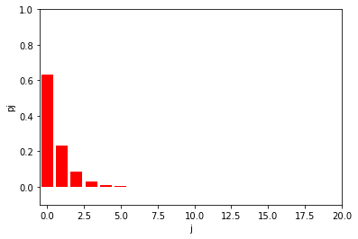

```python
%matplotlib inline
import numpy as np
from matplotlib import pyplot as plt
bho = 1
N = 20
x = np.zeros(N)
y = np.zeros(N)
for j in range(0,N):
    x[j] = j
    y[j] = (1-np.exp(-bho))*(np.exp(-bho))**j
plt.bar(x, y, label = '', color = 'red')
plt.xlabel('j')
plt.ylabel('pj')
#plt.legend()
axes = plt.gca()
axes.set_xlim([0-0.5,N])
axes.set_ylim([-0.1,1])
plt.show()
```

## Variáveis contínuas

Neste caso, lidaremos com observáveis que possuem um espectro contínuo, i.e., seu conjunto de valores possível não é enumerável como no exemplo acima.

### Densidade de probabilidade

Como não faz sentido falar na probabilidade de um valor específico de $X$, usamos a densidade de probabilidade $\rho(x)$, que é a probabilidade por intervalo infinitesimal $dx$ de valores de $X$. Teremos assim que \begin{equation} \rho(x)dx = \text{probabilidade de obter o valor de } X \text{ entre } x \text{ e } x+dx. \end{equation}

Se conhecemos a função $\rho(x)$, para calcular a frequência relativa com que valores de $X$ são obtidos dentro de um certo intervalo finito $[a,b]$ simplesmente somamos as probabilidades nos sub-intervalos infinitesimais aí: \begin{equation} Pr(x\in[a,b]) = \int_{a}^{b} \rho(x)dx. \end{equation}

Analogamente ao caso discreto, teremos a seguinte condição de normalização para a distribuição de probabilidades \begin{equation} \int_{-\infty}^{+\infty} \rho(x)dx = 1. \end{equation}

### Valor médio e desvio padrão

O cálculo dessas quantidades para variáveis contínuas segue a mesma idea que para variáveis discretas, ou seja, \begin{align} \langle X \rangle & = \int_{-\infty}^{+\infty} x\rho(x)dx, \\ \langle f(X) \rangle & = \int_{-\infty}^{+\infty} f(x)\rho(x)dx, \\ \sigma_{X}^{2} & = \langle (X - \langle X \rangle)^{2} \rangle = \int_{-\infty}^{+\infty} (x - \langle X \rangle)^{2}\rho(x)dx = \langle X^{2} \rangle - \langle X \rangle^{2}. \\ \end{align}

### Exemplo: Distribuição Gaussiana de velocidades

Esta é uma das DP mais importantes para a ciência e tem a forma \begin{equation} \rho_{G}(x) = \frac{1}{\sqrt{2\pi \sigma^{2}}}e^{-(x-\mu)^{2}/2\sigma^{2}}. \end{equation}

#### Integral Gaussiana $G = \int_{-\infty}^{\infty}e^{-ax^{2}}dx = \sqrt{\frac{\pi}{a}}$

Fazemos essa integral notando que \begin{align} G^{2} & = \left(\int_{-\infty}^{\infty}e^{-ax^{2}}dx\right)\left(\int_{-\infty}^{\infty}e^{-ay^{2}}dy\right) \\ & = \int_{-\infty}^{\infty}\int_{-\infty}^{\infty} e^{-a(x^{2}+y^{2})} dx dy. \end{align} Agora mudamos de coordenadas retangulares para polares: $x = r\cos\theta$, $y = r\sin\theta$, $da = dxdy = rdrd\theta$ com $x\in(-\infty,\infty)$, $y\in(-\infty,\infty)$, $\theta\in[0,\infty)$, $\theta\in[0,2\pi)$. Assim \begin{align} G^{2} & = \int_{0}^{\infty}\int_{0}^{2\pi} e^{-ar^2} rdrd\theta \\ & = 2\pi\int_{0}^{-\infty} e^{u} \frac{-du}{2a} \\ & = \frac{\pi}{a}. \end{align}

```python
x, a = symbols('x a')
integrate(exp(-a*x**2),(x,-oo,oo))
```

$$\begin{cases} \frac{\sqrt{\pi}}{\sqrt{a}} & \text{for}\: \left|{\operatorname{periodic_{argument}}{\left (a,\infty \right )}}\right| \leq \frac{\pi}{2} \\\int_{-\infty}^{\infty} e^{- a x^{2}}\, dx & \text{otherwise} \end{cases}$$

**Exercício:** Verifique que $\int_{-\infty}^{\infty}\rho_{G}(x)dx = 1$.

Com isso já podemos calcular o valor médio de $X$ com DP Gaussiana: \begin{align} \langle X \rangle & = \int_{-\infty}^{\infty} x\rho_{G}(x)dx \\ & = \int_{-\infty}^{\infty} x\frac{1}{\sqrt{2\pi \sigma^{2}}}e^{-(x-\mu)^{2}/2\sigma^{2}}dx. \end{align} Fazendo a mudança de variável $y = (x-\mu)/\sqrt{2}\sigma \therefore dy=dx/\sqrt{2}\sigma$ obtemos (para $\mu$ finito) \begin{align} \langle X \rangle & = \frac{1}{\sqrt{2\pi \sigma^{2}}}\int_{-\infty}^{\infty} (\sqrt{2}\sigma y+\mu)e^{-y^{2}} \sqrt{2} \sigma dy \\ & = \frac{1}{\sqrt{2\pi \sigma^{2}}}\left (2\sigma^{2}\int_{-\infty}^{\infty}y e^{-y^{2}}dy + \sqrt{2}\sigma\mu \int_{-\infty}^{\infty} e^{-y^{2}}dy \right) \\ & = \frac{1}{\sqrt{2\pi \sigma^{2}}}\left (2\sigma^{2}0 + \sqrt{2}\sigma\mu\sqrt{\pi/1} \right) \\ & = \mu. \end{align} Acima a primeira integral é nula pois envolve uma função ímpar.

#### Integrais relacionadas à Gaussiana obtidas usando o truque de Feynman

Primeiro notemos que $\partial_{a}e^{-a x^{2}} = -x^{2}e^{-a x^{2}}$.

```python
diff(exp(-a*x**2),a)
```

$$- x^{2} e^{- a x^{2}}$$

Isso pode ser usado para a integral \begin{align} \int_{-\infty}^{\infty} x^{2}e^{-ax^{2}}dx & = \int_{-\infty}^{\infty} (-\partial_{a}e^{-a x^{2}})dx \\ & = -\partial_{a}\int_{-\infty}^{\infty} e^{-a x^{2}}dx \\ & = -\partial_{a}\sqrt{\pi/a} \\ & = \sqrt{\pi/4 a^{3}}. \end{align}

```python
x, a = symbols('x a')
integrate((x**2)*exp(-a*x**2),(x,-oo,oo))
```

$$\begin{cases} \frac{\sqrt{\pi}}{2 a^{\frac{3}{2}}} & \text{for}\: \left|{\operatorname{periodic_{argument}}{\left (a,\infty \right )}}\right| < \frac{\pi}{2} \\\int_{-\infty}^{\infty} x^{2} e^{- a x^{2}}\, dx & \text{otherwise} \end{cases}$$

Teremos assim que \begin{align} \langle X^{2} \rangle & = \int_{-\infty}^{\infty} x^{2} \rho_{G}(x)dx \\ & = \frac{1}{\sqrt{2\pi \sigma^{2}}} \int_{-\infty}^{\infty} x^{2} e^{-(x-\mu)^{2}/2\sigma^{2}}dx \\ & = \frac{1}{\sqrt{2\pi \sigma^{2}}} \int_{-\infty}^{\infty} \left(\sqrt{2}\sigma y+\mu\right)^{2} e^{-y^{2}}\sqrt{2}\sigma dy \\ & = \frac{1}{\sqrt{\pi}} \int_{-\infty}^{\infty} \left(2\sigma^{2}y^{2}+2\sqrt{2}\sigma\mu y+\mu^{2}\right) e^{-y^{2}}dy \\ & = \frac{1}{\sqrt{\pi}} \left(2\sigma^{2}\int_{-\infty}^{\infty} y^{2} e^{-y^{2}}dy + 2\sqrt{2}\sigma\mu\int_{-\infty}^{\infty} y e^{-y^{2}}dy + \mu^{2}\int_{-\infty}^{\infty} e^{-y^{2}}dy \right) \\ & = \frac{1}{\sqrt{\pi}} \left(2\sigma^{2}\sqrt{\pi/4} + 2\sqrt{2}\sigma\mu0 + \mu^{2}\sqrt{\pi} \right) \\ & = \sigma^{2} + \mu^{2}. \end{align}

#### 'Desvio padrão'

\begin{align} \sigma_{X}^{2} & = \langle X^{2} \rangle - \langle X \rangle^{2} \\ & = \sigma^{2} + \mu^{2} - \mu^{2} \\ & = \sigma^{2}. \end{align}

```
Distribuição de probabilidades Gaussiana
```

```
No handles with labels found to put in legend.
```

[output not shown]

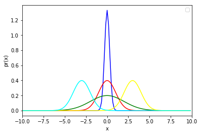

```python
print('Distribuição de probabilidades Gaussiana')
%matplotlib inline
import numpy as np
from matplotlib import pyplot as plt
from math import sqrt, exp, pi
mu1 = 0
sd1 = 0.3
mu2 = 0
sd2 = 1
mu3 = 0
sd3 = 2
mu4 = 3
sd4 = 1
mu5 = -3
sd5 = 1
N = 60
x = np.zeros(2*N)
y1 = np.zeros(2*N)
y2 = np.zeros(2*N)
y3 = np.zeros(2*N)
y4 = np.zeros(2*N)
y5 = np.zeros(2*N)
for j in range(0,2*N):
    x[j] = (j-N)/6
    y1[j] = (1/sqrt(2*pi*sd1**2))*exp(-((x[j]-mu1)**2)/(2*sd1**2))
    y2[j] = (1/sqrt(2*pi*sd2**2))*exp(-((x[j]-mu2)**2)/(2*sd2**2))
    y3[j] = (1/sqrt(2*pi*sd3**2))*exp(-((x[j]-mu3)**2)/(2*sd3**2))
    y4[j] = (1/sqrt(2*pi*sd4**2))*exp(-((x[j]-mu4)**2)/(2*sd4**2))
    y5[j] = (1/sqrt(2*pi*sd5**2))*exp(-((x[j]-mu5)**2)/(2*sd5**2))
plt.plot(x, y1, label = '', color = 'blue')
plt.plot(x, y2, label = '', color = 'red')
plt.plot(x, y3, label = '', color = 'green')
plt.plot(x, y4, label = '', color = 'yellow')
plt.plot(x, y5, label = '', color = 'cyan')
plt.xlabel('x')
plt.ylabel('pr(x)')
plt.legend()
axes = plt.gca()
axes.set_xlim([-10,10])
axes.set_ylim([-0.1,])
plt.show()
```

### Teorema do limite central (TLC)

Para qualquer variável aleatória $X$, se a medimos um número finito de vezes, o valor médio obtido será também uma variável aleatória. O TLC diz que a distribuição de probabilidades de $\langle X \rangle$ é a distribuição normal. Vamos considerar como exemplo um dado. Vamos fazer $M$ experimentos, cada um com $N$ rolagens do dado. Em cada experimento obteremos um certo valor médio do valor do dado. Vamos então graficar a distribuição de probabilidades desses valores médios.

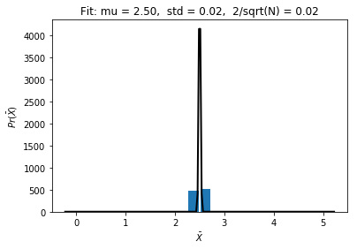

```python
# M jogos, cada um com N roladas do dado
from numpy import random;  random.seed()
from scipy.stats import norm

M = 1000;  N = 2**13
avg = np.zeros(M)
for j in range(0,M):
    p = np.zeros(6)
    for k in range(0,N):
        rn = random.random()
        for l in range(0,6):
            if rn >= l/6. and rn < (l+1)/6.:
                p[l] += 1
    for l in range(0,6):
        p[l] = p[l]/N
        avg[j] += l*p[l]

bins = [0, 0.25, 0.5, 0.75, 1, 1.25, 1.5, 1.75, 2, 2.25, 2.5, 2.75, 3, 3.25, 3.5, 3.75, 4, 4.25, 4.5, 4.75, 5]
plt.hist(avg, bins, histtype='bar', rwidth=0.8)

mu, std = norm.fit(avg)
xmin, xmax = plt.xlim()
x = np.linspace(xmin, xmax, 200)
p = (M/4)*norm.pdf(x, mu, std)
plt.plot(x, p, 'k', linewidth=2)
title = "Fit: mu = %.2f,  std = %.2f,  2/sqrt(N) = %.2f" % (mu, std, 2/sqrt(N))
plt.title(title)

plt.xlabel(r'$\bar{X}$')
plt.ylabel(r'$Pr(\bar{X})$')
plt.show()
```